# Cardiovascular Disease and Air Quality

Jack Grafton

4/24/2018

# Introduction

It is already known that bad air quality can lead to cardiovasucular issues (R. D. Brook et al. 2010). What does this relationship look like, however, in change since 1980? Seeing the result of that data will help reveal the degree of importance air quality is to cardiovascular health. This project analyzes the change in death rate from cardiovascular disease(Health Metrics and (IHME) 2017) vs the change in Air Quality Index from 1980 to 2014((EPA) 2017), and how they may relate.

# Methods

Data in this report is taken from databanks within the EPA and IMHE. This data is then turned into figures that help the viewer see the relationship between the two sets of data for each: change in death rate from caridovasulcar disease from 1980-2014, and change in air quality index from 1980-2014.

# Results

Result figures show maps that represent change in aqi and change in cardiovascular death rate over 1980 to 2014.The second map (Figure 2) shows the change in mortality from cardiovascular disease. The midpoint for this map is the average of all states’ data: -47%; this is compared to the state AQI change’s midpoint of 0%. The third map highlights state AQI changes that are either positive or negative.

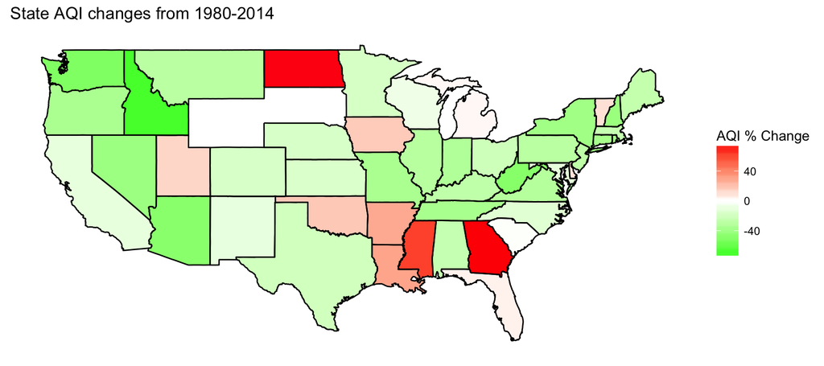

Figure 1: This map shows state AQI changes since 1980. Darker red values indicate higher aqi, while darker green values indicate lower aqi.

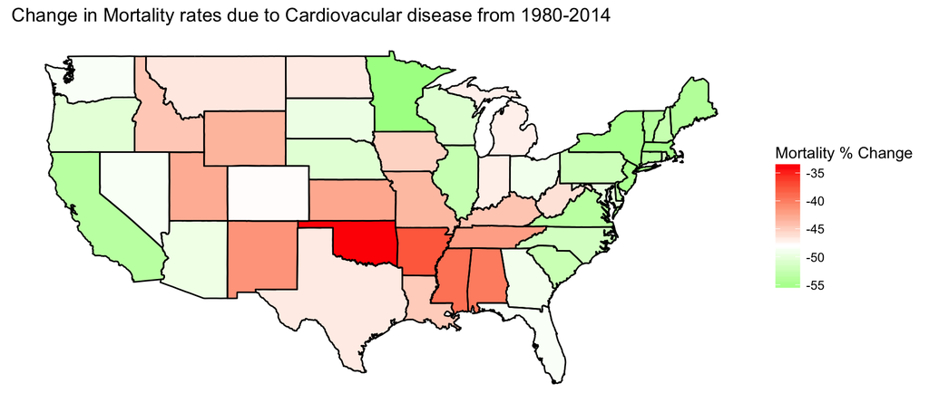

Figure 2: This map shows change in mortality from cardiovasular disease. Green values indicate greater improvement, while red values indicate lower improvement based on a midpoint change mean of -48%.

This next map shows additional analysis for comparison; it shows the states that increased in AQI and states that decreased in AQI.

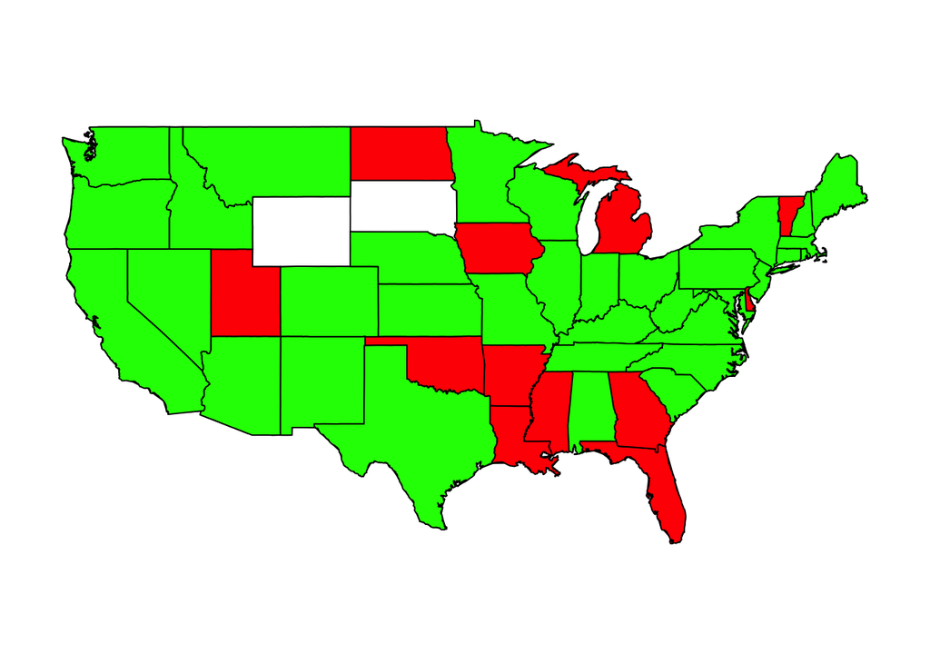

Figure 3: Red states increased in AQI since 1980, while green states decreased. White states do not have enough data to determine change.

# Discussion

In an overall analysis, there seems to be some similarity between the change in cardiovascular death rate and the change in Air Quality Index. This similarity is especially evident in some of the southern states. While death rates due to cardiovascular disease have gone down, the rates that did not go down as much can be compared to aqi levels that have not improved much or gotten worse.

For the rest of the United States that haven’t been discussed, there doesn’t seem to be much correlation, which could be due to various other factors that influence cardiovascular disease rates much more than air quality. Idaho had the most improved air quality out of all ofall states, yet still had below average improvement in cardiovascular disease rate. Another study could analyze particulate matter emission changes vs. ozone changes, and then compare that to the cardiovascular disease change presented here. For this project, they are put together in an AQI. However these different substance could vary in concentrations across the US, and one could contribute to the development of cardiovascular disease more often than the other.

# Conclusion

# References

Brook, R. D., S. Rajagopalan, C. A. Pope, J. R. Brook, A. Bhatnagar, A. V. Diez-Roux, F. Holguin, et al. 2010. “Particulate Matter Air Pollution and Cardiovascular Disease: An Update to the Scientific Statement from the American Heart Association.” *Circulation* 121 (21). Ovid Technologies (Wolters Kluwer Health): 2331–78. doi:10.1161/cir.0b013e3181dbece1.

(EPA), Environmental Protection Agency. 2017. “Annual Aqi by County, 1980-2014.” https://aqs.epa.gov/aqsweb/airdata/download_files.html.

Health Metrics, Institute for, and Evaluation (IHME). 2017. “United States Cardiovascular Disease Mortality Rates by County 1980-2014.” http://ghdx.healthdata.org/record/united-states-cardiovascular-disease-mortality-rates-county-1980-2014.